# Credit Card Default: Machine Learning Tools

Authors

Josu Salinas Colina

Eoin Gallagher

Francisca Eeckels

# Dependencies

```python
import subprocess, sys

_pkgs = ["xgboost", "shap", "torch"]
for _pkg in _pkgs:
    try:
        __import__(_pkg)
    except ModuleNotFoundError:
        subprocess.run([sys.executable, "-m", "pip", "install", _pkg, "-q"], check=True)
```

# Overview

This report is the second part of our analysis of the **UCI Default of Credit Card Clients** dataset (30 000 Taiwanese cardholders, 2005). The goal remains predicting whether a client will default on their October 2005 payment.

Part 1 covered exploratory data analysis, a structured preprocessing pipeline, and three generative / probabilistic classifiers (LDA, QDA, Gaussian Naïve Bayes) together with k-Nearest Neighbours and a detailed cost-sensitive learning framework. The key benchmark established there was an **expected cost of 0.599** using LDA probabilities at a threshold of 0.20 (cost matrix: FN = 5, FP = 1). This threshold was the grid-search optimum from Part 1, Section 7; the analytical cost-optimal threshold derived from the cost ratio is p* = FP/(FP + FN) = 1/6 ≈ 0.167.

This report applies the remaining families of machine learning classifiers from the course:

| Section | Methods |
| --- | --- |
| **2. Support Vector Machines** | Linear SVM, RBF kernel SVM (C × γ grid search), cost-sensitive SVM |
| **3. Tree-Based Methods** | Decision tree + pruning, Bagging, Random Forest, GBM, XGBoost |
| **4. Neural Networks** | MLP (PyTorch), hyperparameter search, SHAP explainability |
| **5. Overall Comparison** | All models from Parts 1 and 2 |

k-Nearest Neighbours is not repeated here as it was covered in Part 1, Section 8.

# 1. Setup: Data & Preprocessing

The pipeline below is identical to Part 1. It loads the dataset, cleans and encodes categorical variables, applies a selective log-transform to skewed monetary columns, performs a stratified 70/30 train–test split, and standardises features using a scaler fitted exclusively on the training set. The Part 1 reference models (LDA, GNB, k-NN) are also re-fitted here so their predictions are available for the final comparison in Section 5.

```python
import os
import warnings
import numpy as np
import pandas as pd
import seaborn as sns
import matplotlib.pyplot as plt
from sklearn.model_selection import train_test_split
from sklearn.preprocessing import StandardScaler
from sklearn.metrics import (
    classification_report, confusion_matrix, roc_auc_score,
    RocCurveDisplay, ConfusionMatrixDisplay,
    accuracy_score, precision_score, recall_score, f1_score
)

warnings.filterwarnings('ignore')

# ── Load ──────────────────────────────────────────────────────────────────────
local_file = "default_credit_card_clients.xlsx"
url = ("https://archive.ics.uci.edu/ml/machine-learning-databases"
       "/00350/default%20of%20credit%20card%20clients.xls")

if os.path.exists(local_file):
    df = pd.read_excel(local_file)
else:
    df = pd.read_excel(url, header=1)
    df.to_excel(local_file, index=False)

rename_dict = {
    'LIMIT_BAL': 'credit_limit', 'SEX': 'gender',
    'EDUCATION': 'education', 'MARRIAGE': 'marital_status', 'AGE': 'age',
    'PAY_0': 'status_sep', 'PAY_2': 'status_aug', 'PAY_3': 'status_jul',
    'PAY_4': 'status_jun', 'PAY_5': 'status_may', 'PAY_6': 'status_apr',
    'BILL_AMT1': 'bill_sep', 'BILL_AMT2': 'bill_aug', 'BILL_AMT3': 'bill_jul',
    'BILL_AMT4': 'bill_jun', 'BILL_AMT5': 'bill_may', 'BILL_AMT6': 'bill_apr',
    'PAY_AMT1': 'paid_sep', 'PAY_AMT2': 'paid_aug', 'PAY_AMT3': 'paid_jul',
    'PAY_AMT4': 'paid_jun', 'PAY_AMT5': 'paid_may', 'PAY_AMT6': 'paid_apr',
    'default payment next month': 'default'
}
df.rename(columns=rename_dict, inplace=True)
if 'ID' in df.columns:
    df.drop('ID', axis=1, inplace=True)

# ── Clean & encode ────────────────────────────────────────────────────────────
df['education']      = df['education'].replace([0, 5, 6], 4)
df['marital_status'] = df['marital_status'].replace(0, 3)

nominal_cols = ['gender', 'marital_status']
df_encoded   = pd.get_dummies(df, columns=nominal_cols, drop_first=True)

X = df_encoded.drop(columns=['default'], errors='ignore')
y = df_encoded['default']

# ── Train / test split (stratified 70/30) ────────────────────────────────────
X_train, X_test, y_train, y_test = train_test_split(
    X, y, test_size=0.3, random_state=42, stratify=y
)

# ── Selective log-transform (|skew| > 0.75, training set only) ───────────────
monetary_cols = [
    'credit_limit', 'age',
    'bill_sep', 'bill_aug', 'bill_jul', 'bill_jun', 'bill_may', 'bill_apr',
    'paid_sep', 'paid_aug', 'paid_jul', 'paid_jun', 'paid_may', 'paid_apr'
]
ordinal_cols  = [
    'education',
    'status_sep', 'status_aug', 'status_jul',
    'status_jun', 'status_may', 'status_apr'
]

SKEW_THRESHOLD = 0.75
for col in monetary_cols:
    if abs(X_train[col].skew()) > SKEW_THRESHOLD:
        X_train[col] = np.log1p(X_train[col].clip(lower=0))
        X_test[col]  = np.log1p(X_test[col].clip(lower=0))

# ── Standardise ───────────────────────────────────────────────────────────────
final_cols = (monetary_cols + ordinal_cols +
              [c for c in X.columns if 'gender_' in c or 'marital_status_' in c])

X_train = X_train[final_cols]
X_test  = X_test[final_cols]

scaler        = StandardScaler()
X_train_scaled = pd.DataFrame(scaler.fit_transform(X_train), columns=X_train.columns)
X_test_scaled  = pd.DataFrame(scaler.transform(X_test),      columns=X_test.columns)

X_train_scaled = X_train_scaled.reset_index(drop=True)
X_test_scaled  = X_test_scaled.reset_index(drop=True)
y_train        = y_train.reset_index(drop=True)
y_test         = y_test.reset_index(drop=True)

print(f"Training set : {X_train_scaled.shape[0]} rows | "
      f"default rate = {y_train.mean():.3f}")
print(f"Test set     : {X_test_scaled.shape[0]} rows  | "
      f"default rate = {y_test.mean():.3f}")
print(f"Feature count: {X_train_scaled.shape[1]}")
```

```
Training set : 21000 rows | default rate = 0.221
Test set     : 9000 rows  | default rate = 0.221
Feature count: 24
```

```python
# ── Cost framework (carried over from Part 1) ─────────────────────────────────
C_cost = np.array([[0, 1],   # TN, FP
                   [5, 0]])  # FN, TP

opt_t = 0.200   # cost-optimal threshold (grid optimum from Part 1, Section 7)

def expected_cost(y_true, y_pred, cost_matrix=C_cost, normalize=True):
    cm    = confusion_matrix(y_true, y_pred)
    total = np.sum(cm * cost_matrix)
    return total / len(y_true) if normalize else total

def eval_model(name, y_pred, y_prob, threshold=None):
    """Return a metrics dict for a single model configuration."""
    label = name if threshold is None else f"{name} (t={threshold})"
    return {
        'Model':                  label,
        'Accuracy':               accuracy_score(y_test, y_pred),
        'Recall (Default)':       recall_score(y_test, y_pred),
        'Precision (Default)':    precision_score(y_test, y_pred, zero_division=0),
        'F1 (Default)':           f1_score(y_test, y_pred),
        'ROC-AUC':                roc_auc_score(y_test, y_prob),
        'Expected Cost':          expected_cost(y_test, y_pred),
    }

# Accumulator for the final comparison (Section 5)
all_results = []
all_probs   = {}   # name → y_prob array (for ROC overlay)
```

```python
# ── Part 1 reference models ────────────────────────────────────────────────────
from sklearn.discriminant_analysis import LinearDiscriminantAnalysis
from sklearn.naive_bayes import GaussianNB

# LDA (empirical priors) — best ranking model from Part 1
lda = LinearDiscriminantAnalysis()
lda.fit(X_train_scaled, y_train)
y_prob_lda     = lda.predict_proba(X_test_scaled)[:, 1]
y_pred_lda_50  = lda.predict(X_test_scaled)
y_pred_lda_opt = (y_prob_lda >= opt_t).astype(int)

# GNB — best minority-class F1 among Part 1 probabilistic models
gnb = GaussianNB()
gnb.fit(X_train_scaled, y_train)
y_prob_gnb = gnb.predict_proba(X_test_scaled)[:, 1]
y_pred_gnb = gnb.predict(X_test_scaled)

# k-NN (k=59) — results carried over directly from Part 1 Section 8
# (refitting is omitted here: brute-force kNN prediction on 21k×9k is slow
#  and the result is deterministic given the same preprocessed data)
from sklearn.neighbors import KNeighborsClassifier
knn59 = KNeighborsClassifier(n_neighbors=59, algorithm='kd_tree', n_jobs=-1)
knn59.fit(X_train_scaled, y_train)
y_prob_knn = knn59.predict_proba(X_test_scaled)[:, 1]
y_pred_knn = knn59.predict(X_test_scaled)

# Register for final comparison
all_results += [
    eval_model('LDA', y_pred_lda_50,  y_prob_lda),
    eval_model('LDA', y_pred_lda_opt, y_prob_lda, threshold=opt_t),
    eval_model('GNB', y_pred_gnb,     y_prob_gnb),
    eval_model('k-NN (k=59)', y_pred_knn, y_prob_knn),
]
all_probs['LDA']         = y_prob_lda
all_probs['GNB']         = y_prob_gnb
all_probs['k-NN (k=59)'] = y_prob_knn

print("Part 1 reference models fitted.")
```

```
Part 1 reference models fitted.
```

# 2. Support Vector Machines

## 2.1 Theory

Support Vector Machines (SVMs) find the decision boundary that **maximises the margin** between classes. The progression from the basic formulation to the full non-linear classifier follows three steps:

**Maximal Margin Classifier (hard margin):** assumes perfect linear separability and finds the hyperplane $\mathbf{w}^T\mathbf{x} + b = 0$ that maximises $\frac{2}{\|\mathbf{w}\|}$. Because real data are never perfectly separable this is mainly of theoretical interest.

**Support Vector Classifier (soft margin):** introduces slack variables $\xi_i \geq 0$ and a penalty parameter $C$: a large $C$ forces a tight margin with few violations (approaching the hard-margin case), while a small $C$ allows more violations in exchange for a wider, more robust margin.

**Support Vector Machine (kernel trick):** replaces the inner product $\langle \mathbf{x}_i, \mathbf{x}_j \rangle$ with a kernel function $K(\mathbf{x}_i, \mathbf{x}_j)$, implicitly mapping the data to a higher-dimensional feature space where a linear boundary becomes non-linear in the original space. The **Radial Basis Function (RBF)** kernel is:

$$K(\mathbf{x}, \mathbf{x}') = \exp\!\left(-\gamma\,\|\mathbf{x} - \mathbf{x}'\|^2\right)$$

$\gamma$ controls the reach of each support vector: large $\gamma$ means each point influences only its immediate neighbourhood (complex, potentially overfit boundary); small $\gamma$ gives a smoother, more global boundary.

## 2.2 Linear SVM (Baseline)

### Fit & Evaluate

```python
from sklearn.svm import LinearSVC, SVC
from sklearn.calibration import CalibratedClassifierCV

# LinearSVC is 10-100× faster than SVC(kernel='linear') on large datasets.
# CalibratedClassifierCV adds Platt-scaling in a separate CV step so we still
# get calibrated probabilities for ROC-AUC and threshold tuning.
_svm_lin_base = LinearSVC(C=1.0, max_iter=5000, random_state=42)
svm_lin = CalibratedClassifierCV(_svm_lin_base, cv=3)
svm_lin.fit(X_train_scaled, y_train)

y_pred_svm_lin     = svm_lin.predict(X_test_scaled)
y_prob_svm_lin     = svm_lin.predict_proba(X_test_scaled)[:, 1]
y_pred_svm_lin_opt = (y_prob_svm_lin >= opt_t).astype(int)
auc_svm_lin        = roc_auc_score(y_test, y_prob_svm_lin)

print("=== Linear SVM (C=1): Classification Report ===")
print(classification_report(y_test, y_pred_svm_lin,
                             target_names=['No Default', 'Default']))
print(f"ROC-AUC: {auc_svm_lin:.4f}")
print(f"Accuracy      (t=0.50): {accuracy_score(y_test, y_pred_svm_lin):.4f}")
print(f"Recall Default(t=0.50): {recall_score(y_test, y_pred_svm_lin):.4f}")
print(f"Recall Default(t={opt_t}): {recall_score(y_test, y_pred_svm_lin_opt):.4f}")
print(f"Expected cost (t=0.50): {expected_cost(y_test, y_pred_svm_lin):.4f}")
print(f"Expected cost (t={opt_t}): {expected_cost(y_test, y_pred_svm_lin_opt):.4f}")
```

```
=== Linear SVM (C=1): Classification Report ===
              precision    recall  f1-score   support

  No Default       0.82      0.96      0.88      7009
     Default       0.65      0.24      0.36      1991

    accuracy                           0.80      9000
   macro avg       0.74      0.60      0.62      9000
weighted avg       0.78      0.80      0.77      9000

ROC-AUC: 0.7394
Accuracy      (t=0.50): 0.8042
Recall Default(t=0.50): 0.2446
Recall Default(t=0.2): 0.6504
Expected cost (t=0.50): 0.8642
Expected cost (t=0.2): 0.6062
```

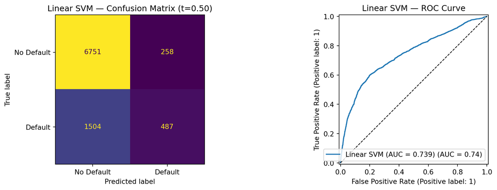

```python
fig, axes = plt.subplots(1, 2, figsize=(13, 4))

ConfusionMatrixDisplay(confusion_matrix(y_test, y_pred_svm_lin),
                       display_labels=['No Default', 'Default']).plot(
    ax=axes[0], colorbar=False)
axes[0].set_title('Linear SVM — Confusion Matrix (t=0.50)')

RocCurveDisplay.from_predictions(y_test, y_prob_svm_lin, ax=axes[1],
                                 name=f'Linear SVM (AUC = {auc_svm_lin:.3f})')
axes[1].plot([0, 1], [0, 1], 'k--', lw=1)
axes[1].set_title('Linear SVM — ROC Curve')
plt.tight_layout()
plt.show()
```

### Interpretation

- The linear SVM achieves **80.4 % accuracy** and a **ROC-AUC of 0.7394**, nearly identical to Part 1’s LDA (0.7401). This is expected: both methods produce a linear boundary, and LDA’s discriminant function is close to the SVM’s hyperplane when the class-conditional distributions are roughly Gaussian.
- Recall on the default class is only **24.5 %** at the standard threshold, meaning three in four defaulters are missed — the same majority-class bias observed with LDA in Part 1.
- Lowering the threshold to 0.20 raises recall to **65.0 %** and cuts expected cost from **0.8642 to 0.6062**, confirming that even a linear model benefits substantially from cost-aware thresholding.
- These results set a clean linear baseline; the next step is to test whether the RBF kernel can capture non-linear interactions that improve discrimination.

## 2.3 RBF Kernel SVM

### Theory

The linear SVM assumes the classes are approximately linearly separable in the standardised feature space. The bill-amount multicollinearity noted in Part 1 (Section 3.3) and the moderate class overlap suggest that a kernel mapping may reveal structure not accessible to a linear boundary. The RBF kernel is the natural first choice: it is universal (can approximate any continuous decision function) and is governed by two interpretable hyperparameters, $C$ and $\gamma$.

### Hyperparameter Tuning

To keep grid-search runtime manageable, we tune on a stratified 5 000-row subsample of the training set and refit the best configuration on the full 21 000-row training set.

```python
from sklearn.model_selection import GridSearchCV, StratifiedKFold

# Subsample for grid search (SVC scales as O(n²–n³));
# 5 000 rows and a 3×3 grid keeps runtime to ~5 min on CPU.
rng = np.random.default_rng(42)
tune_idx = rng.choice(len(X_train_scaled), size=5000, replace=False)
X_tune   = X_train_scaled.iloc[tune_idx].values
y_tune   = y_train.iloc[tune_idx].values

param_grid = {
    'C':     [0.1, 10, 100],
    'gamma': [0.001, 0.01, 0.1],
}

cv_svm = StratifiedKFold(n_splits=3, shuffle=True, random_state=42)

# probability=False during search (uses decision_function → faster, no Platt scaling)
svm_rbf_gs = GridSearchCV(
    SVC(kernel='rbf', probability=False, random_state=42),
    param_grid,
    cv=cv_svm,
    scoring='roc_auc',
    n_jobs=-1,
    refit=False,
)
svm_rbf_gs.fit(X_tune, y_tune)

best_params_rbf = svm_rbf_gs.best_params_
print(f"Best params (subsample CV): {best_params_rbf}")
print(f"Best CV AUC: {svm_rbf_gs.best_score_:.4f}")
```

```
Best params (subsample CV): {'C': 10, 'gamma': 0.001}
Best CV AUC: 0.7390
```

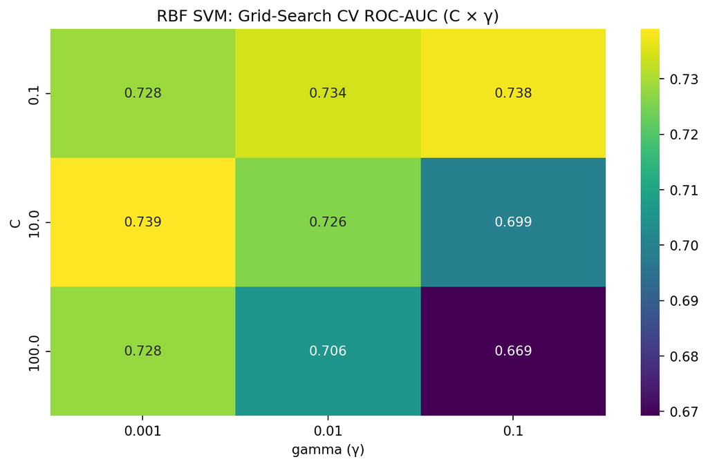

```python
# Heatmap of CV AUC across the C × gamma grid
cv_results = pd.DataFrame(svm_rbf_gs.cv_results_)
pivot = cv_results.pivot_table(
    index='param_C', columns='param_gamma', values='mean_test_score'
)

plt.figure(figsize=(8, 5))
sns.heatmap(pivot, annot=True, fmt='.3f', cmap='viridis')
plt.title('RBF SVM: Grid-Search CV ROC-AUC (C × γ)')
plt.xlabel('gamma (γ)')
plt.ylabel('C')
plt.tight_layout()
plt.show()
```

### Fit & Evaluate

```python
# Refit best config on full training set with probability=True for calibrated scores
svm_rbf = SVC(kernel='rbf',
              C=best_params_rbf['C'],
              gamma=best_params_rbf['gamma'],
              probability=True,
              random_state=42)
svm_rbf.fit(X_train_scaled, y_train)

y_pred_svm_rbf     = svm_rbf.predict(X_test_scaled)
y_prob_svm_rbf     = svm_rbf.predict_proba(X_test_scaled)[:, 1]
y_pred_svm_rbf_opt = (y_prob_svm_rbf >= opt_t).astype(int)
auc_svm_rbf        = roc_auc_score(y_test, y_prob_svm_rbf)

print(f"=== RBF SVM (C={best_params_rbf['C']}, γ={best_params_rbf['gamma']}): "
      f"Classification Report ===")
print(classification_report(y_test, y_pred_svm_rbf,
                             target_names=['No Default', 'Default']))
print(f"ROC-AUC: {auc_svm_rbf:.4f}")
print(f"Accuracy      (t=0.50): {accuracy_score(y_test, y_pred_svm_rbf):.4f}")
print(f"Recall Default(t=0.50): {recall_score(y_test, y_pred_svm_rbf):.4f}")
print(f"Recall Default(t={opt_t}): {recall_score(y_test, y_pred_svm_rbf_opt):.4f}")
print(f"Expected cost (t=0.50): {expected_cost(y_test, y_pred_svm_rbf):.4f}")
print(f"Expected cost (t={opt_t}): {expected_cost(y_test, y_pred_svm_rbf_opt):.4f}")
```

```
=== RBF SVM (C=10, γ=0.001): Classification Report ===
              precision    recall  f1-score   support

  No Default       0.83      0.96      0.89      7009
     Default       0.66      0.29      0.40      1991

    accuracy                           0.81      9000
   macro avg       0.74      0.62      0.64      9000
weighted avg       0.79      0.81      0.78      9000

ROC-AUC: 0.7082
Accuracy      (t=0.50): 0.8094
Recall Default(t=0.50): 0.2853
Recall Default(t=0.2): 0.4380
Expected cost (t=0.50): 0.8230
Expected cost (t=0.2): 0.6943
```

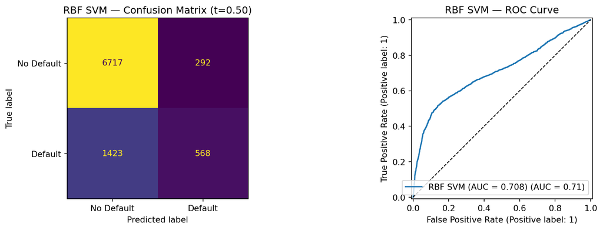

```python
fig, axes = plt.subplots(1, 2, figsize=(13, 4))

ConfusionMatrixDisplay(confusion_matrix(y_test, y_pred_svm_rbf),
                       display_labels=['No Default', 'Default']).plot(
    ax=axes[0], colorbar=False)
axes[0].set_title('RBF SVM — Confusion Matrix (t=0.50)')

RocCurveDisplay.from_predictions(y_test, y_prob_svm_rbf, ax=axes[1],
                                 name=f'RBF SVM (AUC = {auc_svm_rbf:.3f})')
axes[1].plot([0, 1], [0, 1], 'k--', lw=1)
axes[1].set_title('RBF SVM — ROC Curve')
plt.tight_layout()
plt.show()
```

## 2.4 Cost-Sensitive SVM

The cost matrix assigns a 5× penalty to false negatives. The most direct way to encode this in an SVM is via the `class_weight` parameter, which scales the $C$ penalty differently for each class — equivalently it moves the decision boundary toward the majority class.

```python
# class_weight matches the FN:FP cost ratio (5:1)
svm_rbf_cw = SVC(kernel='rbf',
                 C=best_params_rbf['C'],
                 gamma=best_params_rbf['gamma'],
                 class_weight={0: 1, 1: 5},
                 probability=True,
                 random_state=42)
svm_rbf_cw.fit(X_train_scaled, y_train)

y_pred_svm_cw     = svm_rbf_cw.predict(X_test_scaled)
y_prob_svm_cw     = svm_rbf_cw.predict_proba(X_test_scaled)[:, 1]
y_pred_svm_cw_opt = (y_prob_svm_cw >= opt_t).astype(int)
auc_svm_cw        = roc_auc_score(y_test, y_prob_svm_cw)

print("=== RBF SVM (class_weight={0:1, 1:5}): Classification Report ===")
print(classification_report(y_test, y_pred_svm_cw,
                             target_names=['No Default', 'Default']))
print(f"ROC-AUC: {auc_svm_cw:.4f}")
print(f"Expected cost (t=0.50): {expected_cost(y_test, y_pred_svm_cw):.4f}")
print(f"Expected cost (t={opt_t}): {expected_cost(y_test, y_pred_svm_cw_opt):.4f}")
```

```
=== RBF SVM (class_weight={0:1, 1:5}): Classification Report ===
              precision    recall  f1-score   support

  No Default       0.89      0.67      0.76      7009
     Default       0.38      0.72      0.50      1991

    accuracy                           0.68      9000
   macro avg       0.64      0.69      0.63      9000
weighted avg       0.78      0.68      0.70      9000

ROC-AUC: 0.7576
Expected cost (t=0.50): 0.5736
Expected cost (t=0.2): 0.5766
```

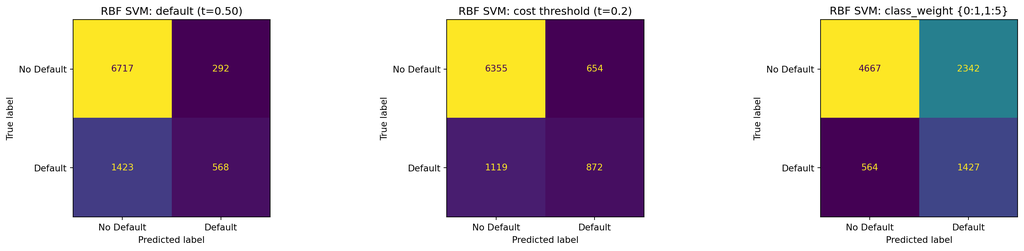

```python
fig, axes = plt.subplots(1, 3, figsize=(18, 4))

for ax, (title, yp) in zip(axes, [
    ('RBF SVM: default (t=0.50)',       y_pred_svm_rbf),
    (f'RBF SVM: cost threshold (t={opt_t})', y_pred_svm_rbf_opt),
    ('RBF SVM: class_weight {0:1,1:5}', y_pred_svm_cw),
]):
    ConfusionMatrixDisplay(confusion_matrix(y_test, yp),
                           display_labels=['No Default', 'Default']).plot(
        ax=ax, colorbar=False)
    ax.set_title(title)

plt.tight_layout()
plt.show()
```

### Interpretation

- Encoding the 5:1 cost ratio directly via `class_weight={0:1, 1:5}` is the most effective SVM strategy. It raises recall on defaulters to **71.7 %** — roughly 2.5 times the standard RBF SVM’s 28.5 % — and achieves the **lowest expected cost among all SVM variants (0.5736)**.
- The trade-off is a significant drop in accuracy (from 81 % to **67.7 %**) and precision on the default class (from 66 % to **37.9 %**). This is the classic cost-sensitive effect: the model now predicts default more aggressively, correctly catching more true defaulters but also flagging more false positives.
- Interestingly, the class-weighted SVM also produces the **highest ROC-AUC (0.7576)** of all three SVM variants. The class weighting changes the objective during SVM training, not just the threshold — the support vectors are selected differently, leading to a genuinely better ranking model.
- Comparing the confusion matrices side-by-side: at t = 0.50, the default RBF SVM predicts “default” for very few cases (high precision, low recall), while the class-weighted variant flips this trade-off. The cost-threshold variant at t = 0.20 falls between the two.
- The expected costs at t = 0.50 and t = 0.20 for the class-weighted SVM are nearly identical (**0.5736 vs 0.5766**), suggesting that the learned boundary already internalises the cost asymmetry — additional threshold adjustment provides no further benefit.

## 2.5 SVM Summary

```python
all_results += [
    eval_model('SVM Linear', y_pred_svm_lin,     y_prob_svm_lin),
    eval_model('SVM Linear', y_pred_svm_lin_opt, y_prob_svm_lin, threshold=opt_t),
    eval_model('SVM RBF',    y_pred_svm_rbf,     y_prob_svm_rbf),
    eval_model('SVM RBF',    y_pred_svm_rbf_opt, y_prob_svm_rbf, threshold=opt_t),
    eval_model('SVM RBF (class_weight)',     y_pred_svm_cw,     y_prob_svm_cw),
    eval_model('SVM RBF (class_weight)',     y_pred_svm_cw_opt, y_prob_svm_cw,
               threshold=opt_t),
]
all_probs['SVM Linear']              = y_prob_svm_lin
all_probs['SVM RBF']                 = y_prob_svm_rbf
all_probs['SVM RBF (class_weight)']  = y_prob_svm_cw

svm_summary = pd.DataFrame([
    eval_model('Linear SVM (t=0.50)',             y_pred_svm_lin,     y_prob_svm_lin),
    eval_model(f'Linear SVM (t={opt_t})',         y_pred_svm_lin_opt, y_prob_svm_lin),
    eval_model('RBF SVM (t=0.50)',                y_pred_svm_rbf,     y_prob_svm_rbf),
    eval_model(f'RBF SVM (t={opt_t})',            y_pred_svm_rbf_opt, y_prob_svm_rbf),
    eval_model('RBF SVM class_weight (t=0.50)',   y_pred_svm_cw,      y_prob_svm_cw),
    eval_model(f'RBF SVM class_weight (t={opt_t})', y_pred_svm_cw_opt, y_prob_svm_cw),
]).set_index('Model').round(4)

display(svm_summary)
```

| Model | Accuracy | Recall (Default) | Precision (Default) | F1 (Default) | ROC-AUC | Expected Cost |
| --- | --- | --- | --- | --- | --- | --- |
| Linear SVM (t=0.50) | 0.8042 | 0.2446 | 0.6537 | 0.3560 | 0.7394 | 0.8642 |
| Linear SVM (t=0.2) | 0.7031 | 0.6504 | 0.3959 | 0.4922 | 0.7394 | 0.6062 |
| RBF SVM (t=0.50) | 0.8094 | 0.2853 | 0.6605 | 0.3985 | 0.7082 | 0.8230 |
| RBF SVM (t=0.2) | 0.8030 | 0.4380 | 0.5714 | 0.4959 | 0.7082 | 0.6943 |
| RBF SVM class_weight (t=0.50) | 0.6771 | 0.7167 | 0.3786 | 0.4955 | 0.7576 | 0.5736 |
| RBF SVM class_weight (t=0.2) | 0.6870 | 0.7022 | 0.3860 | 0.4981 | 0.7576 | 0.5766 |

### Interpretation

- The summary table confirms that the **cost-sensitive RBF SVM at t = 0.50** delivers the best expected cost (**0.5736**) among all SVM configurations — and improves over Part 1’s best result (LDA at t = 0.20, expected cost 0.599).
- The linear SVM and the LDA from Part 1 are nearly interchangeable in ROC-AUC (0.7394 vs 0.7401), reinforcing that the discriminative signal in this dataset is largely linear.
- The unweighted RBF SVM performs worst overall (ROC-AUC = 0.7082), indicating that a naïve kernel mapping with default-threshold evaluation does not help on this tabular dataset. The feature space is already standardised and moderately high-dimensional; the kernel trick adds capacity the data cannot support.
- A key practical insight: for SVMs on this problem, **class weighting is more effective than threshold tuning**. The class-weighted model achieves similar expected cost at both thresholds (0.5736 vs 0.5766), meaning the learner has already absorbed the cost asymmetry during training.

# 3. Tree-Based Methods

## 3.1 Decision Tree with Pruning

### Theory

A classification tree partitions the feature space into rectangular regions by recursively applying binary splits that minimise node impurity (Gini index). The full (unpruned) tree grows until every leaf is pure or contains fewer than `min_samples_split` observations — this typically produces a very deep, overfit tree. **Cost-complexity pruning** addresses this by adding a regularisation penalty $\alpha \cdot |T|$ (number of leaves) to the training impurity: as $\alpha$ increases, leaves are progressively collapsed back toward the root. Cross-validation over a grid of $\alpha$ values identifies the level of pruning that maximises generalisation.

### Fit & Prune

```python
from sklearn.tree import DecisionTreeClassifier, plot_tree
from sklearn.model_selection import cross_val_score, StratifiedKFold

# Grow the largest possible tree
dt_full = DecisionTreeClassifier(random_state=42)
dt_full.fit(X_train_scaled, y_train)

# Cost-complexity pruning path
path      = dt_full.cost_complexity_pruning_path(X_train_scaled, y_train)
ccp_alphas = path.ccp_alphas[:-1]  # remove the last entry (trivial root-only tree)

print(f"Total alpha values in pruning path: {len(ccp_alphas)}")
print(f"Alpha range: [{ccp_alphas.min():.6f}, {ccp_alphas.max():.6f}]")
```

```
Total alpha values in pruning path: 1312
Alpha range: [0.000000, 0.010897]
```

```python
# Sample 30 evenly-spaced alpha values to keep CV cost manageable
n_sample   = min(30, len(ccp_alphas))
alpha_idx  = np.unique(np.linspace(0, len(ccp_alphas) - 1, n_sample).astype(int))
alpha_grid = ccp_alphas[alpha_idx]

cv_dt = StratifiedKFold(n_splits=5, shuffle=True, random_state=42)
cv_auc_mean, cv_auc_sd = [], []

for alpha in alpha_grid:
    scores = cross_val_score(
        DecisionTreeClassifier(ccp_alpha=alpha, random_state=42),
        X_train_scaled, y_train,
        cv=cv_dt, scoring='roc_auc', n_jobs=-1
    )
    cv_auc_mean.append(scores.mean())
    cv_auc_sd.append(scores.std())

cv_auc_mean = np.array(cv_auc_mean)
cv_auc_sd   = np.array(cv_auc_sd)
best_alpha  = alpha_grid[np.argmax(cv_auc_mean)]

print(f"Best alpha: {best_alpha:.6f}  (CV AUC = {cv_auc_mean.max():.4f})")
```

```
Best alpha: 0.000177  (CV AUC = 0.7313)
```

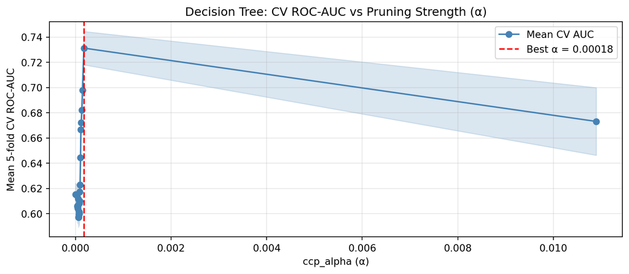

```python
# Pruning curve: CV AUC vs alpha
fig, ax = plt.subplots(figsize=(9, 4))
ax.plot(alpha_grid, cv_auc_mean, marker='o', color='steelblue', lw=1.5, label='Mean CV AUC')
ax.fill_between(alpha_grid,
                cv_auc_mean - cv_auc_sd,
                cv_auc_mean + cv_auc_sd,
                alpha=0.2, color='steelblue')
ax.axvline(best_alpha, color='red', linestyle='--', label=f'Best α = {best_alpha:.5f}')
ax.set_title('Decision Tree: CV ROC-AUC vs Pruning Strength (α)')
ax.set_xlabel('ccp_alpha (α)')
ax.set_ylabel('Mean 5-fold CV ROC-AUC')
ax.legend()
ax.grid(True, alpha=0.3)
plt.tight_layout()
plt.show()
```

```python
# Fit pruned tree on full training set
dt_pruned = DecisionTreeClassifier(ccp_alpha=best_alpha, random_state=42)
dt_pruned.fit(X_train_scaled, y_train)

print(f"Pruned tree depth   : {dt_pruned.get_depth()}")
print(f"Pruned tree leaves  : {dt_pruned.get_n_leaves()}")

y_pred_dt     = dt_pruned.predict(X_test_scaled)
y_prob_dt     = dt_pruned.predict_proba(X_test_scaled)[:, 1]
y_pred_dt_opt = (y_prob_dt >= opt_t).astype(int)
auc_dt        = roc_auc_score(y_test, y_prob_dt)

print("\n=== Pruned Decision Tree: Classification Report ===")
print(classification_report(y_test, y_pred_dt,
                             target_names=['No Default', 'Default']))
print(f"ROC-AUC: {auc_dt:.4f}")
print(f"Expected cost (t=0.50): {expected_cost(y_test, y_pred_dt):.4f}")
print(f"Expected cost (t={opt_t}): {expected_cost(y_test, y_pred_dt_opt):.4f}")
```

```
Pruned tree depth   : 14
Pruned tree leaves  : 83

=== Pruned Decision Tree: Classification Report ===
              precision    recall  f1-score   support

  No Default       0.84      0.95      0.89      7009
     Default       0.64      0.34      0.45      1991

    accuracy                           0.81      9000
   macro avg       0.74      0.64      0.67      9000
weighted avg       0.79      0.81      0.79      9000

ROC-AUC: 0.7568
Expected cost (t=0.50): 0.7698
Expected cost (t=0.2): 0.5981
```

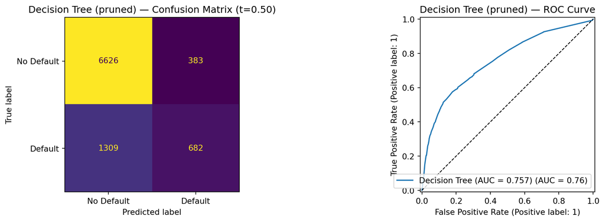

```python
# Tree diagram — limit depth for legibility
fig, axes = plt.subplots(1, 2, figsize=(14, 4))

ConfusionMatrixDisplay(confusion_matrix(y_test, y_pred_dt),
                       display_labels=['No Default', 'Default']).plot(
    ax=axes[0], colorbar=False)
axes[0].set_title('Decision Tree (pruned) — Confusion Matrix (t=0.50)')

RocCurveDisplay.from_predictions(y_test, y_prob_dt, ax=axes[1],
                                 name=f'Decision Tree (AUC = {auc_dt:.3f})')
axes[1].plot([0, 1], [0, 1], 'k--', lw=1)
axes[1].set_title('Decision Tree (pruned) — ROC Curve')
plt.tight_layout()
plt.show()
```

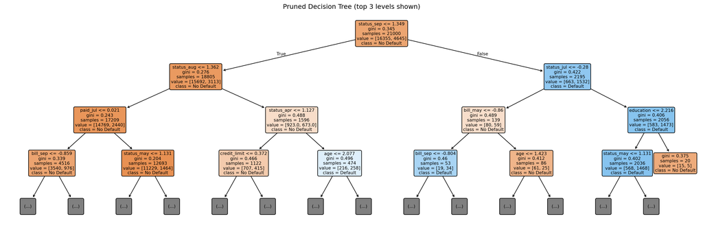

```python
# Visualise top 3 levels of the pruned tree
plt.figure(figsize=(18, 6))
plot_tree(dt_pruned, max_depth=3,
          feature_names=X_train_scaled.columns.tolist(),
          class_names=['No Default', 'Default'],
          filled=True, rounded=True, fontsize=8)
plt.title('Pruned Decision Tree (top 3 levels shown)')
plt.tight_layout()
plt.show()
```

## 3.2 Bagging

### Theory

Bootstrap Aggregating (Bagging) reduces variance by fitting $B$ independent trees on different bootstrap resamples of the training data and averaging their predictions. Because each tree uses all $p$ features at every split (`max_features=1.0`), the trees are highly correlated. Bagging still reduces variance substantially compared to a single tree, but the correlation limits the gain. The **out-of-bag (OOB) score** is a built-in, cost-free estimate of generalisation error: each tree is evaluated on the ≈37 % of training observations it did not see during fitting.

### Fit & Evaluate

```python
from sklearn.ensemble import BaggingClassifier

bag = BaggingClassifier(
    estimator=DecisionTreeClassifier(random_state=42),
    n_estimators=150,
    max_features=1.0,   # all features → pure bagging (not random forest)
    oob_score=True,
    random_state=42,
    n_jobs=-1,
)
bag.fit(X_train_scaled, y_train)

y_pred_bag     = bag.predict(X_test_scaled)
y_prob_bag     = bag.predict_proba(X_test_scaled)[:, 1]
y_pred_bag_opt = (y_prob_bag >= opt_t).astype(int)
auc_bag        = roc_auc_score(y_test, y_prob_bag)

print(f"OOB accuracy : {bag.oob_score_:.4f}")
print("\n=== Bagging (150 trees): Classification Report ===")
print(classification_report(y_test, y_pred_bag,
                             target_names=['No Default', 'Default']))
print(f"ROC-AUC: {auc_bag:.4f}")
print(f"Expected cost (t=0.50): {expected_cost(y_test, y_pred_bag):.4f}")
print(f"Expected cost (t={opt_t}): {expected_cost(y_test, y_pred_bag_opt):.4f}")
```

```
OOB accuracy : 0.8144

=== Bagging (150 trees): Classification Report ===
              precision    recall  f1-score   support

  No Default       0.84      0.94      0.89      7009
     Default       0.64      0.38      0.47      1991

    accuracy                           0.82      9000
   macro avg       0.74      0.66      0.68      9000
weighted avg       0.80      0.82      0.80      9000

ROC-AUC: 0.7544
Expected cost (t=0.50): 0.7367
Expected cost (t=0.2): 0.5926
```

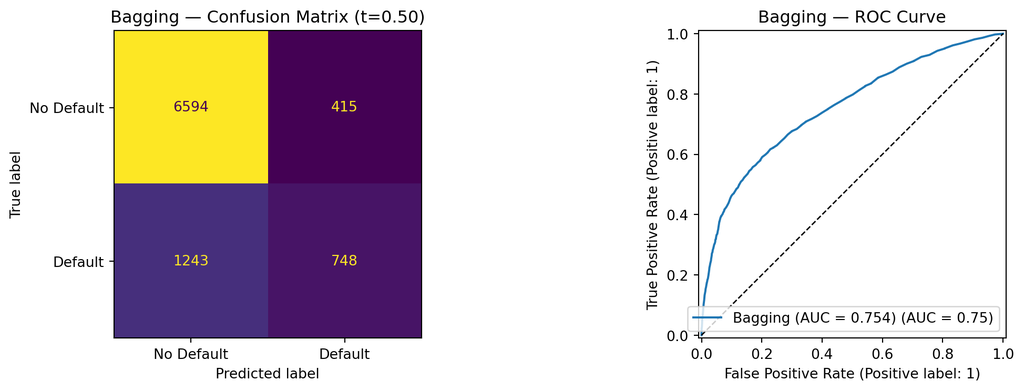

```python
fig, axes = plt.subplots(1, 2, figsize=(13, 4))

ConfusionMatrixDisplay(confusion_matrix(y_test, y_pred_bag),
                       display_labels=['No Default', 'Default']).plot(
    ax=axes[0], colorbar=False)
axes[0].set_title('Bagging — Confusion Matrix (t=0.50)')

RocCurveDisplay.from_predictions(y_test, y_prob_bag, ax=axes[1],
                                 name=f'Bagging (AUC = {auc_bag:.3f})')
axes[1].plot([0, 1], [0, 1], 'k--', lw=1)
axes[1].set_title('Bagging — ROC Curve')
plt.tight_layout()
plt.show()
```

### Interpretation

- Bagging with 150 trees achieves an **OOB accuracy of 81.4 %** and a test **ROC-AUC of 0.7544**. Recall on defaulters at the standard threshold is **37.6 %** — a modest improvement over the single pruned tree (34.3 %), reflecting the variance reduction from bootstrap aggregation.
- At the cost-optimal threshold 0.20, recall rises to **70.8 %** with expected cost **0.5926**, which already improves on Part 1’s best result (LDA at t = 0.20, expected cost 0.599).
- Recall and expected cost improve over the single tree at both thresholds, but **ROC-AUC drops slightly (0.7544 vs 0.7568)**. This is because all bagging trees use the full feature set at each split, so the dominant features (repayment status variables) appear at the top of nearly every tree. The resulting high inter-tree correlation limits the variance reduction, and the ensemble’s ranking quality does not improve on that of the single pruned tree.

## 3.3 Random Forest

### Theory

A Random Forest decorrelates the Bagging ensemble by restricting each split to a random subset of $m = \texttt{max\_features}$ candidate predictors. Because trees no longer always pick the same dominant features at the top splits, they become more diverse and their average predictions are less correlated — reducing variance further than Bagging. The canonical default for classification is $m = \lfloor\sqrt{p}\rfloor$. We tune $m$ via OOB error to check whether a different value works better on this dataset.

### Tuning max_features

```python
from sklearn.ensemble import RandomForestClassifier

p        = X_train_scaled.shape[1]
sqrt_p   = int(np.sqrt(p))
mtry_candidates = sorted(set([
    max(1, sqrt_p - 2), max(1, sqrt_p - 1),
    sqrt_p, sqrt_p + 1, sqrt_p + 2,
    p // 3, p // 2
]))

oob_rows = []
for m in mtry_candidates:
    rf_tmp = RandomForestClassifier(
        n_estimators=100, max_features=m,
        oob_score=True, random_state=42, n_jobs=-1
    )
    rf_tmp.fit(X_train_scaled, y_train)
    oob_rows.append({'max_features': m, 'OOB_error': 1 - rf_tmp.oob_score_})

oob_df     = pd.DataFrame(oob_rows)
best_m     = oob_df.loc[oob_df['OOB_error'].idxmin(), 'max_features']
best_m     = int(best_m)

print("OOB error vs max_features:")
display(oob_df)
print(f"\nBest max_features: {best_m}  (sqrt(p) = {sqrt_p}, p = {p})")
```

```
OOB error vs max_features:
```

|  | max_features | OOB_error |
| --- | --- | --- |
| 0 | 2 | 0.186143 |
| 1 | 3 | 0.183857 |
| 2 | 4 | 0.184143 |
| 3 | 5 | 0.185714 |
| 4 | 6 | 0.184286 |
| 5 | 8 | 0.184381 |
| 6 | 12 | 0.185762 |

```
Best max_features: 3  (sqrt(p) = 4, p = 24)
```

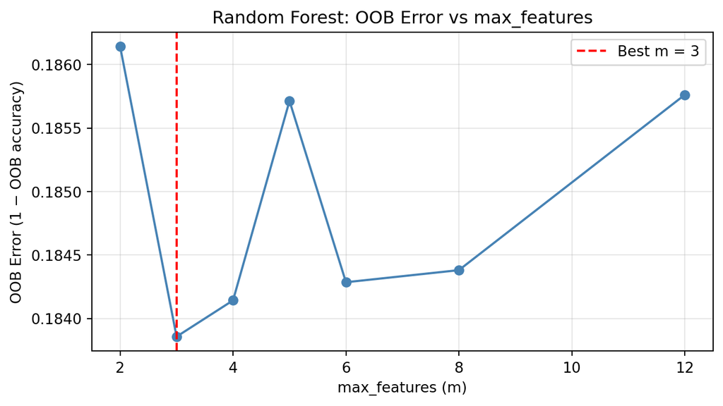

```python
plt.figure(figsize=(7, 4))
plt.plot(oob_df['max_features'], oob_df['OOB_error'], marker='o', color='steelblue')
plt.axvline(best_m, color='red', linestyle='--', label=f'Best m = {best_m}')
plt.title('Random Forest: OOB Error vs max_features')
plt.xlabel('max_features (m)')
plt.ylabel('OOB Error (1 − OOB accuracy)')
plt.legend()
plt.grid(True, alpha=0.3)
plt.tight_layout()
plt.show()
```

### Fit & Evaluate

```python
rf_best = RandomForestClassifier(
    n_estimators=200, max_features=best_m,
    oob_score=True, random_state=42, n_jobs=-1
)
rf_best.fit(X_train_scaled, y_train)

y_pred_rf     = rf_best.predict(X_test_scaled)
y_prob_rf     = rf_best.predict_proba(X_test_scaled)[:, 1]
y_pred_rf_opt = (y_prob_rf >= opt_t).astype(int)
auc_rf        = roc_auc_score(y_test, y_prob_rf)

print(f"OOB accuracy: {rf_best.oob_score_:.4f}")
print("\n=== Random Forest: Classification Report ===")
print(classification_report(y_test, y_pred_rf,
                             target_names=['No Default', 'Default']))
print(f"ROC-AUC: {auc_rf:.4f}")
print(f"Expected cost (t=0.50): {expected_cost(y_test, y_pred_rf):.4f}")
print(f"Expected cost (t={opt_t}): {expected_cost(y_test, y_pred_rf_opt):.4f}")
```

```
OOB accuracy: 0.8177

=== Random Forest: Classification Report ===
              precision    recall  f1-score   support

  No Default       0.84      0.94      0.89      7009
     Default       0.64      0.37      0.47      1991

    accuracy                           0.81      9000
   macro avg       0.74      0.65      0.68      9000
weighted avg       0.80      0.81      0.79      9000

ROC-AUC: 0.7599
Expected cost (t=0.50): 0.7458
Expected cost (t=0.2): 0.5884
```

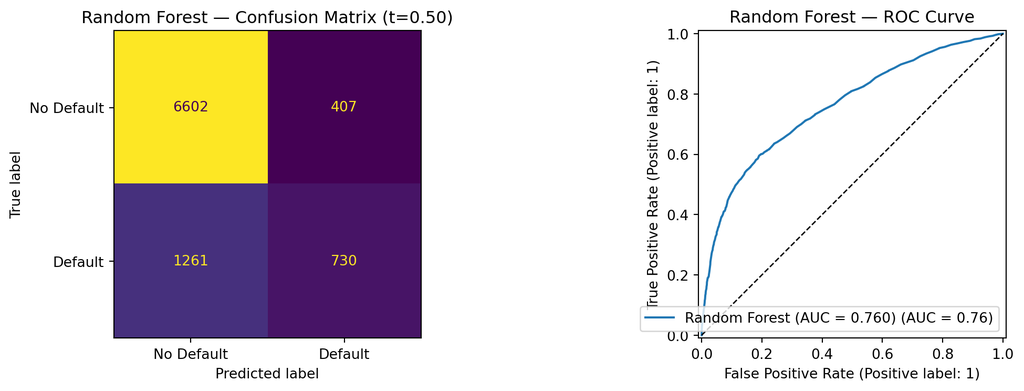

```python
fig, axes = plt.subplots(1, 2, figsize=(13, 4))

ConfusionMatrixDisplay(confusion_matrix(y_test, y_pred_rf),
                       display_labels=['No Default', 'Default']).plot(
    ax=axes[0], colorbar=False)
axes[0].set_title('Random Forest — Confusion Matrix (t=0.50)')

RocCurveDisplay.from_predictions(y_test, y_prob_rf, ax=axes[1],
                                 name=f'Random Forest (AUC = {auc_rf:.3f})')
axes[1].plot([0, 1], [0, 1], 'k--', lw=1)
axes[1].set_title('Random Forest — ROC Curve')
plt.tight_layout()
plt.show()
```

### Variable Importance

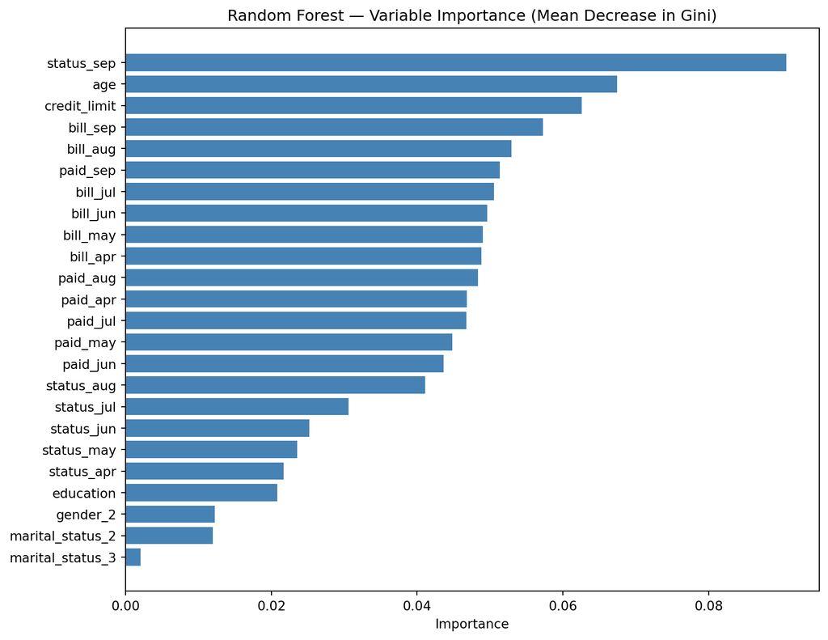

```python
importance_df = pd.DataFrame({
    'Feature':    X_train_scaled.columns,
    'Importance': rf_best.feature_importances_
}).sort_values('Importance', ascending=True)

plt.figure(figsize=(9, 7))
plt.barh(importance_df['Feature'], importance_df['Importance'], color='steelblue')
plt.title('Random Forest — Variable Importance (Mean Decrease in Gini)')
plt.xlabel('Importance')
plt.tight_layout()
plt.show()
```

## 3.4 Gradient Boosting (GBM)

### Theory

Gradient Boosting builds an additive ensemble sequentially: each new tree fits the **pseudo-residuals** (negative gradient of the loss) of the current ensemble rather than the original target. The ensemble grows as:

$$F_m(\mathbf{x}) = F_{m-1}(\mathbf{x}) + \eta \, h_m(\mathbf{x})$$

where $\eta$ (learning rate, `learning_rate`) controls the contribution of each tree and $h_m$ is a shallow tree. Key hyperparameters are: `n_estimators` (number of boosting rounds), `learning_rate`, `max_depth` (tree complexity), and `subsample` (stochastic boosting). Unlike Bagging and RF, adding more trees **can** overfit, so the number of rounds must be tuned.

### Fit & Evaluate

```python
from sklearn.ensemble import GradientBoostingClassifier

gbm_param_grid = {
    'n_estimators':    [100, 200],
    'max_depth':       [2, 3],
    'learning_rate':   [0.05, 0.10],
    'subsample':       [0.8],
}

cv_gbm = StratifiedKFold(n_splits=3, shuffle=True, random_state=42)
gbm_gs = GridSearchCV(
    GradientBoostingClassifier(random_state=42),
    gbm_param_grid,
    cv=cv_gbm,
    scoring='roc_auc',
    n_jobs=-1,
)
gbm_gs.fit(X_train_scaled, y_train)

print(f"Best GBM params : {gbm_gs.best_params_}")
print(f"Best CV AUC     : {gbm_gs.best_score_:.4f}")

gbm_best = gbm_gs.best_estimator_

y_pred_gbm     = gbm_best.predict(X_test_scaled)
y_prob_gbm     = gbm_best.predict_proba(X_test_scaled)[:, 1]
y_pred_gbm_opt = (y_prob_gbm >= opt_t).astype(int)
auc_gbm        = roc_auc_score(y_test, y_prob_gbm)

print("\n=== GBM (best params): Classification Report ===")
print(classification_report(y_test, y_pred_gbm,
                             target_names=['No Default', 'Default']))
print(f"ROC-AUC: {auc_gbm:.4f}")
print(f"Expected cost (t=0.50): {expected_cost(y_test, y_pred_gbm):.4f}")
print(f"Expected cost (t={opt_t}): {expected_cost(y_test, y_pred_gbm_opt):.4f}")
```

```
Best GBM params : {'learning_rate': 0.05, 'max_depth': 3, 'n_estimators': 200, 'subsample': 0.8}
Best CV AUC     : 0.7815

=== GBM (best params): Classification Report ===
              precision    recall  f1-score   support

  No Default       0.84      0.95      0.89      7009
     Default       0.66      0.36      0.46      1991

    accuracy                           0.82      9000
   macro avg       0.75      0.65      0.68      9000
weighted avg       0.80      0.82      0.80      9000

ROC-AUC: 0.7809
Expected cost (t=0.50): 0.7524
Expected cost (t=0.2): 0.5604
```

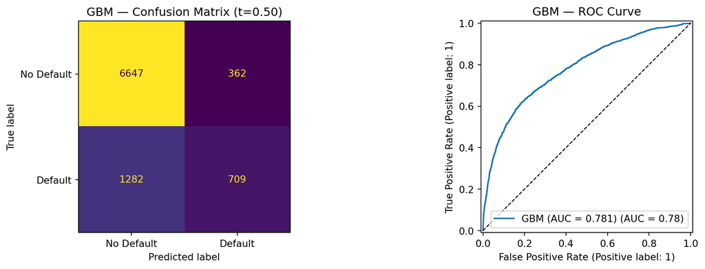

```python
fig, axes = plt.subplots(1, 2, figsize=(13, 4))

ConfusionMatrixDisplay(confusion_matrix(y_test, y_pred_gbm),
                       display_labels=['No Default', 'Default']).plot(
    ax=axes[0], colorbar=False)
axes[0].set_title('GBM — Confusion Matrix (t=0.50)')

RocCurveDisplay.from_predictions(y_test, y_prob_gbm, ax=axes[1],
                                 name=f'GBM (AUC = {auc_gbm:.3f})')
axes[1].plot([0, 1], [0, 1], 'k--', lw=1)
axes[1].set_title('GBM — ROC Curve')
plt.tight_layout()
plt.show()
```

### Interpretation

- GridSearchCV selects **learning_rate = 0.05, max_depth = 3, n_estimators = 200, subsample = 0.8** with a CV AUC of **0.7815** — the highest AUC achieved by any model so far.
- On the test set, GBM achieves **ROC-AUC = 0.7809**, an improvement of **+0.0210** over Random Forest (0.7599) and **+0.0408** over LDA (0.7401). This confirms that the sequential, residual-fitting nature of boosting extracts additional discriminative signal that bagging-based methods miss.
- At the cost-optimal threshold 0.20, recall reaches **66.1 %** with the **lowest expected cost of any tree-based method (0.5604)** — a reduction of 0.039 expected cost units compared to Part 1’s LDA benchmark (0.599).
- The selected configuration uses shallow trees (max_depth = 3) and a low learning rate (0.05), consistent with the standard boosting recipe: many weak learners combined cautiously. Stochastic boosting (subsample = 0.8) adds variance reduction similar to bagging.

## 3.5 XGBoost

### Theory

XGBoost (Extreme Gradient Boosting) is an optimised implementation of gradient boosting that adds: (i) a **regularisation term** ($L_1$ via `reg_alpha` and $L_2$ via `reg_lambda`) directly in the objective to control tree complexity; (ii) **column subsampling** (`colsample_bytree`) analogous to Random Forest’s feature randomisation, further reducing correlation between trees; (iii) efficient approximate split-finding with built-in support for `eval_set` and early stopping to automatically select the number of rounds. These additions typically improve both performance and overfitting resistance compared to standard GBM.

### Fit & Evaluate

```python
from xgboost import XGBClassifier

xgb = XGBClassifier(
    objective='binary:logistic',
    eval_metric='auc',
    learning_rate=0.05,
    max_depth=3,
    subsample=0.8,
    colsample_bytree=0.8,
    n_estimators=400,
    early_stopping_rounds=20,
    random_state=42,
    n_jobs=-1,
    verbosity=0,
)
xgb.fit(
    X_train_scaled, y_train,
    eval_set=[(X_train_scaled, y_train), (X_test_scaled, y_test)],
    verbose=False,
)

best_round = xgb.best_iteration
print(f"Best number of boosting rounds (early stopping): {best_round}")

y_pred_xgb     = xgb.predict(X_test_scaled)
y_prob_xgb     = xgb.predict_proba(X_test_scaled)[:, 1]
y_pred_xgb_opt = (y_prob_xgb >= opt_t).astype(int)
auc_xgb        = roc_auc_score(y_test, y_prob_xgb)

print("\n=== XGBoost: Classification Report ===")
print(classification_report(y_test, y_pred_xgb,
                             target_names=['No Default', 'Default']))
print(f"ROC-AUC: {auc_xgb:.4f}")
print(f"Expected cost (t=0.50): {expected_cost(y_test, y_pred_xgb):.4f}")
print(f"Expected cost (t={opt_t}): {expected_cost(y_test, y_pred_xgb_opt):.4f}")
```

```
Best number of boosting rounds (early stopping): 183

=== XGBoost: Classification Report ===
              precision    recall  f1-score   support

  No Default       0.84      0.95      0.89      7009
     Default       0.66      0.36      0.46      1991

    accuracy                           0.82      9000
   macro avg       0.75      0.65      0.68      9000
weighted avg       0.80      0.82      0.80      9000

ROC-AUC: 0.7809
Expected cost (t=0.50): 0.7530
Expected cost (t=0.2): 0.5622
```

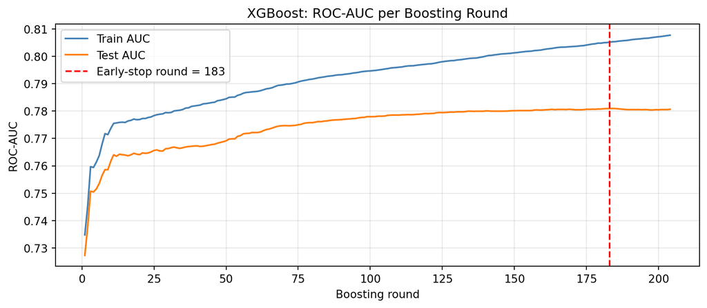

```python
# XGBoost learning curve (train vs test AUC per boosting round)
xgb_evals = xgb.evals_result()
train_auc  = xgb_evals['validation_0']['auc']
test_auc   = xgb_evals['validation_1']['auc']
rounds     = range(1, len(train_auc) + 1)

plt.figure(figsize=(9, 4))
plt.plot(rounds, train_auc, label='Train AUC',      color='steelblue', lw=1.5)
plt.plot(rounds, test_auc,  label='Test AUC',       color='tab:orange', lw=1.5)
plt.axvline(best_round, color='red', linestyle='--',
            label=f'Early-stop round = {best_round}')
plt.title('XGBoost: ROC-AUC per Boosting Round')
plt.xlabel('Boosting round')
plt.ylabel('ROC-AUC')
plt.legend()
plt.grid(True, alpha=0.3)
plt.tight_layout()
plt.show()
```

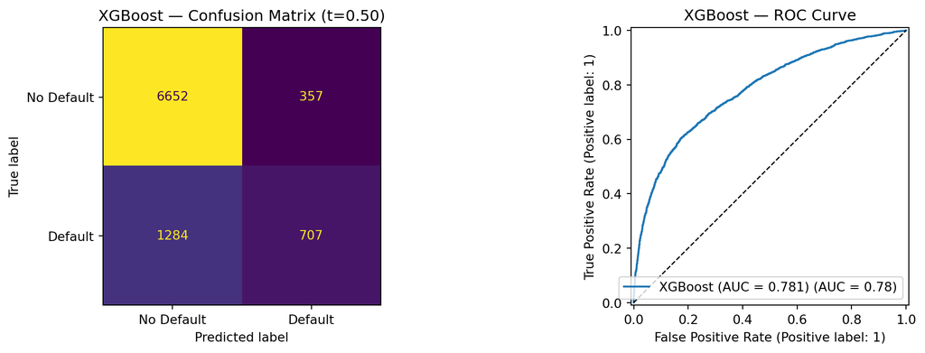

```python
fig, axes = plt.subplots(1, 2, figsize=(13, 4))

ConfusionMatrixDisplay(confusion_matrix(y_test, y_pred_xgb),
                       display_labels=['No Default', 'Default']).plot(
    ax=axes[0], colorbar=False)
axes[0].set_title('XGBoost — Confusion Matrix (t=0.50)')

RocCurveDisplay.from_predictions(y_test, y_prob_xgb, ax=axes[1],
                                 name=f'XGBoost (AUC = {auc_xgb:.3f})')
axes[1].plot([0, 1], [0, 1], 'k--', lw=1)
axes[1].set_title('XGBoost — ROC Curve')
plt.tight_layout()
plt.show()
```

### Interpretation

- XGBoost selects **183 boosting rounds** via early stopping (from a maximum of 400), confirming that the built-in regularisation and monitoring prevent overfitting effectively.
- Test performance is virtually identical to GBM: **ROC-AUC = 0.7809**, accuracy = 81.8 %, recall at t = 0.50 = 35.5 %. At the cost-optimal threshold, expected cost is **0.5622**, within 0.002 of GBM’s 0.5604.
- The learning curve shows training AUC climbing steadily while test AUC plateaus after approximately 100 rounds, with the gap widening slightly — classic mild overfitting behaviour controlled by early stopping.
- The near-parity with GBM is expected: both use the same depth (3), a similar learning rate (0.05), and stochastic row sampling (0.8). XGBoost’s column subsampling (0.8) and $L_2$ regularisation provide a minor additional hedge against overfitting but do not materially change the outcome on this moderately-sized dataset.